# Introduction of WeatherBitRWrapper

## **Getting Started**

Before start using `WeatherBitRWrapper`. You need to set up your Weatherbit API Key.

1. Go to Weatherbit [API website](https://www.weatherbit.io/).
2. Sign up and you will get your API key.

Set your API key into your `.Renviron` file.

1. Opening the `.Renviron` file in RStudio using `file.edit("~/.Renviron")`
2. Add `WEATHERBIT_API_KEY=your_actual_api_key_here` and saving the file.

Next, you can ready to enjoy calling `WeatherBitRWrapper` by run the following code:

```r
# Load the package
library(WeatherBitRWrapper)
```

## Fetch Alert

There are 4 methods to fetch severe weather alerts data. A dataframe with detailed alerts information will be return.

- `weather_alert_lat`: Get alerts by latitude and longitude.
- `weather_alert_city`: Get alerts by city name.
- `weather_alert_postal`: Get alerts by postal code.
- `weather_alert_id`: Get alerts by city id.

**Common arguments**:

- `save_dir`: Directory path, default at ’’. To save query result as a dataframe, assign `save_dir` a valid directory path.

### Get alerts by latitude and longitude

```r
weather_alert_lat <- (
  lat, lon, save_dir = ''
  )
```

**Example**:

```r
# Fetch weather alerts at [49.88307, 119.48568]

df <- WeatherBitRWrapper::weather_alert_lat(lat=49.88307, lon=119.48568)
```

```
#> [1] "Connected to WeatherBit API successfully!"
#> No active weather alerts for the location.
```

```r
kable(df[1:5, ]) %>%
  kable_styling(bootstrap_options = "striped", full_width = FALSE) %>%
  scroll_box(height = "300px")
```

|  | city_name | state_code | country_code | lat | lon | timezone | title | severity | effective_local | expires_local | regions | uri |
| --- | --- | --- | --- | --- | --- | --- | --- | --- | --- | --- | --- | --- |
| 1 | Heishantou | 20 | CN | 49.8831 | 119.4857 | Asia/Shanghai | NA | NA | NA | NA | NA | NA |
| NA | NA | NA | NA | NA | NA | NA | NA | NA | NA | NA | NA | NA |
| NA.1 | NA | NA | NA | NA | NA | NA | NA | NA | NA | NA | NA | NA |
| NA.2 | NA | NA | NA | NA | NA | NA | NA | NA | NA | NA | NA | NA |
| NA.3 | NA | NA | NA | NA | NA | NA | NA | NA | NA | NA | NA | NA |

### Get alerts by city name

```r
weather_alert_city <- (
  city, state = NULL, country = NULL, save_dir = ''
  )
```

**Example**:

```r
# Fetch weather alerts in Kelowna

df <- WeatherBitRWrapper::weather_alert_city(city="Kelowna")
```

```
#> [1] "Connected to WeatherBit API successfully!"
#> No active weather alerts for the location.
```

```r
kable(df[1:5, ]) %>%
  kable_styling(bootstrap_options = "striped", full_width = FALSE) %>%
  scroll_box(height = "300px")
```

|  | city_name | state_code | country_code | lat | lon | timezone | title | severity | effective_local | expires_local | regions | uri |
| --- | --- | --- | --- | --- | --- | --- | --- | --- | --- | --- | --- | --- |
| 1 | Kelowna | BC | CA | 49.88307 | -119.4857 | America/Vancouver | NA | NA | NA | NA | NA | NA |
| NA | NA | NA | NA | NA | NA | NA | NA | NA | NA | NA | NA | NA |
| NA.1 | NA | NA | NA | NA | NA | NA | NA | NA | NA | NA | NA | NA |
| NA.2 | NA | NA | NA | NA | NA | NA | NA | NA | NA | NA | NA | NA |
| NA.3 | NA | NA | NA | NA | NA | NA | NA | NA | NA | NA | NA | NA |

```r
# Fetch weather alerts in Kelowna, BC

df <- WeatherBitRWrapper::weather_alert_city(city="Kelowna", state="BC")
```

```
#> [1] "Connected to WeatherBit API successfully!"
#> No active weather alerts for the location.
```

```r
kable(df[1:5, ]) %>%
  kable_styling(bootstrap_options = "striped", full_width = FALSE) %>%
  scroll_box(height = "300px")
```

|  | city_name | state_code | country_code | lat | lon | timezone | title | severity | effective_local | expires_local | regions | uri |
| --- | --- | --- | --- | --- | --- | --- | --- | --- | --- | --- | --- | --- |
| 1 | Kelowna | BC | CA | 49.88307 | -119.4857 | America/Vancouver | NA | NA | NA | NA | NA | NA |
| NA | NA | NA | NA | NA | NA | NA | NA | NA | NA | NA | NA | NA |
| NA.1 | NA | NA | NA | NA | NA | NA | NA | NA | NA | NA | NA | NA |
| NA.2 | NA | NA | NA | NA | NA | NA | NA | NA | NA | NA | NA | NA |
| NA.3 | NA | NA | NA | NA | NA | NA | NA | NA | NA | NA | NA | NA |

```r
# Fetch weather alerts in Kelowna, BC, Canada

df <- WeatherBitRWrapper::weather_alert_city(city="Kelowna", state="BC", country="CA")
```

```
#> [1] "Connected to WeatherBit API successfully!"
#> No active weather alerts for the location.
```

```r
kable(df[1:5, ]) %>%
  kable_styling(bootstrap_options = "striped", full_width = FALSE) %>%
  scroll_box(height = "300px")
```

|  | city_name | state_code | country_code | lat | lon | timezone | title | severity | effective_local | expires_local | regions | uri |
| --- | --- | --- | --- | --- | --- | --- | --- | --- | --- | --- | --- | --- |
| 1 | Kelowna | BC | CA | 49.88307 | -119.4857 | America/Vancouver | NA | NA | NA | NA | NA | NA |
| NA | NA | NA | NA | NA | NA | NA | NA | NA | NA | NA | NA | NA |
| NA.1 | NA | NA | NA | NA | NA | NA | NA | NA | NA | NA | NA | NA |
| NA.2 | NA | NA | NA | NA | NA | NA | NA | NA | NA | NA | NA | NA |
| NA.3 | NA | NA | NA | NA | NA | NA | NA | NA | NA | NA | NA | NA |

### Get alerts by postal code

```r
weather_alert_postal <- (
  postal_code, country = NULL, save_dir = ''
  )
```

**Example**:

```r
# Fetch weather alerts at V1V1V7

df <- WeatherBitRWrapper::weather_alert_postal(postal_code="V1V1V7")
```

```
#> [1] "Connected to WeatherBit API successfully!"
#> No active weather alerts for the location.
```

```r
kable(df[1:5, ]) %>%
  kable_styling(bootstrap_options = "striped", full_width = FALSE) %>%
  scroll_box(height = "300px")
```

|  | city_name | state_code | country_code | lat | lon | timezone | title | severity | effective_local | expires_local | regions | uri |
| --- | --- | --- | --- | --- | --- | --- | --- | --- | --- | --- | --- | --- |
| 1 | Kelowna | BC | CA | 49.9497 | -119.4339 | America/Vancouver | NA | NA | NA | NA | NA | NA |
| NA | NA | NA | NA | NA | NA | NA | NA | NA | NA | NA | NA | NA |
| NA.1 | NA | NA | NA | NA | NA | NA | NA | NA | NA | NA | NA | NA |
| NA.2 | NA | NA | NA | NA | NA | NA | NA | NA | NA | NA | NA | NA |
| NA.3 | NA | NA | NA | NA | NA | NA | NA | NA | NA | NA | NA | NA |

```r
# Fetch weather alerts at V1V1V7, Canada

df <- WeatherBitRWrapper::weather_alert_postal(postal_code="V1V1V7", country="CA")
```

```
#> [1] "Connected to WeatherBit API successfully!"
#> No active weather alerts for the location.
```

```r
kable(df[1:5, ]) %>%
  kable_styling(bootstrap_options = "striped", full_width = FALSE) %>%
  scroll_box(height = "300px")
```

|  | city_name | state_code | country_code | lat | lon | timezone | title | severity | effective_local | expires_local | regions | uri |
| --- | --- | --- | --- | --- | --- | --- | --- | --- | --- | --- | --- | --- |
| 1 | Kelowna | BC | CA | 49.9497 | -119.4339 | America/Vancouver | NA | NA | NA | NA | NA | NA |
| NA | NA | NA | NA | NA | NA | NA | NA | NA | NA | NA | NA | NA |
| NA.1 | NA | NA | NA | NA | NA | NA | NA | NA | NA | NA | NA | NA |
| NA.2 | NA | NA | NA | NA | NA | NA | NA | NA | NA | NA | NA | NA |
| NA.3 | NA | NA | NA | NA | NA | NA | NA | NA | NA | NA | NA | NA |

### Get alerts by city id

```r
weather_alert_id <- (
  city_id, save_dir = ''
  )
```

**Example**:

```r
# Fetch weather alerts at 8953360

df <- WeatherBitRWrapper::weather_alert_id(city_id=8953360)
```

```
#> [1] "Connected to WeatherBit API successfully!"
```

```r
kable(df[, c("lon", "timezone")]) %>%
  kable_styling(bootstrap_options = "striped", full_width = FALSE)
```

| lon | timezone |
| --- | --- |
| 12.88979 | Europe/Rome |

## Fetch Forecast Weather

There are 4 methods to fetch forecast weather data. A dataframe with forecast data will be return.

- `get_forecast_by_city`: Get forecast weather by city name.
- `get_forecast_by_lat_lon`: Get forecast weather by latitude and longitude. (Recommended)
- `get_forecast_by_postal_code`: Get forecast weather by postal.
- `get_forecast_by_city_id`: Get forecast by city id.

**Common arguments**:

- `save_dir`: Directory path, default at ’’. To save query result as a dataframe, assign `save_dir` a valid directory path.
- `language`: Weatherbit API supports a list of language as return. `English` is the default language.Other available options: Available language list:
  - `en` - [DEFAULT] English
  - `ar` - Arabic
  - `az` - Azerbaijani
  - `be` - Belarusian
  - `bg` - Bulgarian
  - `bs` - Bosnian
  - `ca` - Catalan
  - `cz` - Czech
  - `da` - Danish
  - `de` - German
  - `fi` - Finnish
  - `fr` - French
  - `el` - Greek
  - `es` - Spanish
  - `et` - Estonian
  - `ja` - Japanese
  - `hr` - Croation
  - `hu` - Hungarian
  - `id` - Indonesian
  - `it` - Italian
  - `is` - Icelandic
  - `iw` - Hebrew
  - `kw` - Cornish
  - `lt` - Lithuanian
  - `nb` - Norwegian Bokmål
  - `nl` - Dutch
  - `pl` - Polish
  - `pt` - Portuguese
  - `ro` - Romanian
  - `ru` - Russian
  - `sk` - Slovak
  - `sl` - Slovenian
  - `sr` - Serbian
  - `sv` - Swedish
  - `tr` - Turkish
  - `uk` - Ukrainian
  - `zh` - Chinese (Simplified)
  - `zh`-tw - Chinese (Traditional)
- `unit`: Unit used in weather results. Default as `Metric (Celsius, m/s, mm)`. Other options:
  - `M` - [DEFAULT] Metric (Celsius, m/s, mm)
  - `S` - Scientific (Kelvin, m/s, mm)
  - `I` - Fahrenheit (F, mph, in).
- `day`: A specific number of forecast days. Default as 16. The max number is 16.

### Get forecast weather by city name

```r
get_forecast_by_city <- (
  city, save_dir = '', language = 'en', unit = 'M', day = 16
  )
```

**Example**:

```r
# Fetch next 16 days weather in Raleigh, NC.

df <- WeatherBitRWrapper::get_forecast_by_city("Raleigh,NC")
```

```
#> [1] "Connect WeatherBit API success!"
```

```r
kable(df[1:16, ]) %>%
  kable_styling(bootstrap_options = "striped", full_width = FALSE) %>%
  scroll_box(height = "300px")
```

|  | city_name | country_code | data.app_max_temp | data.app_min_temp | data.clouds | data.clouds_hi | data.clouds_low | data.clouds_mid | data.datetime | data.dewpt | data.high_temp | data.low_temp | data.max_dhi | data.max_temp | data.min_temp | data.moon_phase | data.moon_phase_lunation | data.moonrise_ts | data.moonset_ts | data.ozone | data.pop | data.precip | data.pres | data.rh | data.slp | data.snow | data.snow_depth | data.sunrise_ts | data.sunset_ts | … |
| --- | --- | --- | --- | --- | --- | --- | --- | --- | --- | --- | --- | --- | --- | --- | --- | --- | --- | --- | --- | --- | --- | --- | --- | --- | --- | --- | --- | --- | --- | --- |
| 1 | Raleigh | US | 22.7 | 9.7 | 63 | 16 | 68 | 9 | 2025-03-15 | 12.6 | 23.7 | 17.2 | NA | 23.7 | 9.2 | 0.96 | 0.54 | 1742082915 | 1742041190 | 314 | 0 | 0.00 | 1005 | 81 | 1017 | 0 | 0 | 1742037844 | 1742080972 | … |
| 2 | Raleigh | US | 22.7 | 17.7 | 76 | 79 | 60 | 73 | 2025-03-16 | 16.9 | 23.1 | 11.7 | NA | 23.1 | 17.2 | 0.91 | 0.58 | 1742172749 | 1742129036 | 312 | 90 | 25.36 | 1000 | 85 | 1011 | 0 | 0 | 1742124158 | 1742167424 | … |
| 3 | Raleigh | US | 17.4 | 9.5 | 44 | 0 | 45 | 27 | 2025-03-17 | 8.1 | 17.1 | 4.0 | NA | 18.2 | 9.0 | 0.84 | 0.61 | 1742262609 | 1742217060 | 350 | 85 | 10.54 | 1002 | 69 | 1014 | 0 | 0 | 1742210472 | 1742253875 | … |
| 4 | Raleigh | US | 18.7 | 2.8 | 2 | 0 | 0 | 0 | 2025-03-18 | 0.6 | 20.4 | 7.2 | NA | 20.4 | 3.6 | 0.77 | 0.64 | 1742352534 | 1742305351 | 309 | 0 | 0.00 | 1009 | 49 | 1021 | 0 | 0 | 1742296786 | 1742340326 | … |
| 5 | Raleigh | US | 21.6 | 7.5 | 27 | 49 | 0 | 11 | 2025-03-19 | 4.6 | 23.1 | 10.0 | NA | 23.1 | 6.9 | 0.68 | 0.68 | 1742442534 | 1742394006 | 278 | 0 | 0.00 | 1005 | 53 | 1017 | 0 | 0 | 1742383099 | 1742426777 | … |
| 6 | Raleigh | US | 18.1 | 7.7 | 35 | 5 | 28 | 0 | 2025-03-20 | 3.8 | 21.3 | 3.7 | NA | 21.3 | 7.7 | 0.59 | 0.71 | 1742446177 | 1742483115 | 308 | 20 | 0.85 | 1000 | 54 | 1012 | 0 | 0 | 1742469413 | 1742513228 | … |
| 7 | Raleigh | US | 13.1 | -0.9 | 18 | 29 | 1 | 14 | 2025-03-21 | -4.9 | 13.1 | 7.4 | NA | 13.1 | 3.0 | 0.48 | 0.75 | 1742536171 | 1742572724 | 352 | 0 | 0.00 | 1009 | 42 | 1022 | 0 | 0 | 1742555726 | 1742599679 | … |
| NA | NA | NA | NA | NA | NA | NA | NA | NA | NA | NA | NA | NA | NA | NA | NA | NA | NA | NA | NA | NA | NA | NA | NA | NA | NA | NA | NA | NA | NA | … |
| NA.1 | NA | NA | NA | NA | NA | NA | NA | NA | NA | NA | NA | NA | NA | NA | NA | NA | NA | NA | NA | NA | NA | NA | NA | NA | NA | NA | NA | NA | NA | … |
| NA.2 | NA | NA | NA | NA | NA | NA | NA | NA | NA | NA | NA | NA | NA | NA | NA | NA | NA | NA | NA | NA | NA | NA | NA | NA | NA | NA | NA | NA | NA | … |
| NA.3 | NA | NA | NA | NA | NA | NA | NA | NA | NA | NA | NA | NA | NA | NA | NA | NA | NA | NA | NA | NA | NA | NA | NA | NA | NA | NA | NA | NA | NA | … |
| NA.4 | NA | NA | NA | NA | NA | NA | NA | NA | NA | NA | NA | NA | NA | NA | NA | NA | NA | NA | NA | NA | NA | NA | NA | NA | NA | NA | NA | NA | NA | … |
| NA.5 | NA | NA | NA | NA | NA | NA | NA | NA | NA | NA | NA | NA | NA | NA | NA | NA | NA | NA | NA | NA | NA | NA | NA | NA | NA | NA | NA | NA | NA | … |
| NA.6 | NA | NA | NA | NA | NA | NA | NA | NA | NA | NA | NA | NA | NA | NA | NA | NA | NA | NA | NA | NA | NA | NA | NA | NA | NA | NA | NA | NA | NA | … |
| NA.7 | NA | NA | NA | NA | NA | NA | NA | NA | NA | NA | NA | NA | NA | NA | NA | NA | NA | NA | NA | NA | NA | NA | NA | NA | NA | NA | NA | NA | NA | … |
| NA.8 | NA | NA | NA | NA | NA | NA | NA | NA | NA | NA | NA | NA | NA | NA | NA | NA | NA | NA | NA | NA | NA | NA | NA | NA | NA | NA | NA | NA | NA | … |

Example to draw a temperature line chart

```r
library(ggplot2)

# Fetch forecast data in Raleigh,NC
weather_data <- WeatherBitRWrapper::get_forecast_by_city("Raleigh,NC", save_dir = './')
```

```
#> [1] "Connect WeatherBit API success!"
#> File forecast_Raleigh_2025-03-15_2025-03-21.csv saved successfully into ./forecast_Raleigh_2025-03-15_2025-03-21.csv.
```

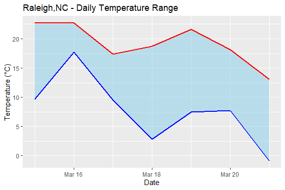

```r
# Convert date format.
weather_data$data.datetime <- as.Date(weather_data$data.datetime)

# Create an area chart
ggplot(weather_data, aes(x = data.datetime)) +
  geom_ribbon(aes(ymin = data.app_min_temp, ymax = data.app_max_temp), fill = "skyblue", alpha = 0.5) +
  geom_line(aes(y = data.app_max_temp), color = "red", linewidth = 1) +   # High temp line
  geom_line(aes(y = data.app_min_temp), color = "blue", linewidth = 1) +   # Low temp line
  labs(title = "Raleigh,NC - Daily Temperature Range",
       x = "Date",
       y = "Temperature (°C)")
```

```r
# Fetch next 16 days weather in Raleigh, NC in Chinese.

df <- WeatherBitRWrapper::get_forecast_by_city("Raleigh,NC", language = "zh")
```

```
#> [1] "Connect WeatherBit API success!"
```

```r
datatable(df, options = list(scrollY = "300px", pageLength = 10))
```

[interactive table not shown]

```r
# Fetch next 16 days weather in Raleigh, NC with Fahrenheit.

df <- WeatherBitRWrapper::get_forecast_by_city("Raleigh,NC", unit = 'I')
```

```
#> [1] "Connect WeatherBit API success!"
```

```r
kable(df[1:16, ]) %>%
  kable_styling(bootstrap_options = "striped", full_width = FALSE) %>%
  scroll_box(height = "300px")
```

|  | city_name | country_code | data.app_max_temp | data.app_min_temp | data.clouds | data.clouds_hi | data.clouds_low | data.clouds_mid | data.datetime | data.dewpt | data.high_temp | data.low_temp | data.max_dhi | data.max_temp | data.min_temp | data.moon_phase | data.moon_phase_lunation | data.moonrise_ts | data.moonset_ts | data.ozone | data.pop | data.precip | data.pres | data.rh | data.slp | data.snow | data.snow_depth | data.sunrise_ts | data.sunset_ts | … |
| --- | --- | --- | --- | --- | --- | --- | --- | --- | --- | --- | --- | --- | --- | --- | --- | --- | --- | --- | --- | --- | --- | --- | --- | --- | --- | --- | --- | --- | --- | --- |
| 1 | Raleigh | US | 72.9 | 49.5 | 64 | 14 | 61 | 13 | 2025-03-15 | 55.9 | 74.3 | 63.0 | NA | 74.3 | 48.6 | 0.96 | 0.54 | 1742082915 | 1742041190 | 314 | 0 | 0.000 | 1005 | 80 | 1017 | 0 | 0 | 1742037844 | 1742080972 | … |
| 2 | Raleigh | US | 72.1 | 64.0 | 79 | 65 | 73 | 68 | 2025-03-16 | 62.6 | 72.9 | 52.3 | NA | 72.9 | 63.0 | 0.91 | 0.58 | 1742172749 | 1742129036 | 312 | 90 | 1.019 | 1000 | 86 | 1012 | 0 | 0 | 1742124158 | 1742167424 | … |
| 3 | Raleigh | US | 63.3 | 48.2 | 43 | 0 | 38 | 0 | 2025-03-17 | 45.7 | 62.2 | 38.3 | NA | 64.8 | 47.1 | 0.84 | 0.61 | 1742262609 | 1742217060 | 350 | 70 | 0.187 | 1003 | 68 | 1015 | 0 | 0 | 1742210472 | 1742253875 | … |
| 4 | Raleigh | US | 65.3 | 36.3 | 2 | 0 | 0 | 0 | 2025-03-18 | 32.4 | 68.5 | 44.4 | NA | 68.5 | 37.9 | 0.77 | 0.64 | 1742352534 | 1742305351 | 309 | 0 | 0.000 | 1009 | 49 | 1021 | 0 | 0 | 1742296786 | 1742340326 | … |
| 5 | Raleigh | US | 70.5 | 45.1 | 23 | 49 | 0 | 11 | 2025-03-19 | 39.4 | 73.2 | 50.4 | NA | 73.2 | 43.9 | 0.68 | 0.68 | 1742442534 | 1742394006 | 278 | 0 | 0.000 | 1005 | 52 | 1017 | 0 | 0 | 1742383099 | 1742426777 | … |
| 6 | Raleigh | US | 64.4 | 45.9 | 33 | 5 | 28 | 0 | 2025-03-20 | 39.2 | 70.5 | 38.7 | NA | 70.5 | 45.9 | 0.59 | 0.71 | 1742446177 | 1742483115 | 308 | 20 | 0.033 | 1000 | 52 | 1012 | 0 | 0 | 1742469413 | 1742513228 | … |
| 7 | Raleigh | US | 55.6 | 30.4 | 18 | 29 | 1 | 14 | 2025-03-21 | 23.2 | 55.6 | 45.3 | NA | 55.6 | 37.4 | 0.48 | 0.75 | 1742536171 | 1742572724 | 352 | 0 | 0.000 | 1009 | 42 | 1022 | 0 | 0 | 1742555726 | 1742599679 | … |
| NA | NA | NA | NA | NA | NA | NA | NA | NA | NA | NA | NA | NA | NA | NA | NA | NA | NA | NA | NA | NA | NA | NA | NA | NA | NA | NA | NA | NA | NA | … |
| NA.1 | NA | NA | NA | NA | NA | NA | NA | NA | NA | NA | NA | NA | NA | NA | NA | NA | NA | NA | NA | NA | NA | NA | NA | NA | NA | NA | NA | NA | NA | … |
| NA.2 | NA | NA | NA | NA | NA | NA | NA | NA | NA | NA | NA | NA | NA | NA | NA | NA | NA | NA | NA | NA | NA | NA | NA | NA | NA | NA | NA | NA | NA | … |
| NA.3 | NA | NA | NA | NA | NA | NA | NA | NA | NA | NA | NA | NA | NA | NA | NA | NA | NA | NA | NA | NA | NA | NA | NA | NA | NA | NA | NA | NA | NA | … |
| NA.4 | NA | NA | NA | NA | NA | NA | NA | NA | NA | NA | NA | NA | NA | NA | NA | NA | NA | NA | NA | NA | NA | NA | NA | NA | NA | NA | NA | NA | NA | … |
| NA.5 | NA | NA | NA | NA | NA | NA | NA | NA | NA | NA | NA | NA | NA | NA | NA | NA | NA | NA | NA | NA | NA | NA | NA | NA | NA | NA | NA | NA | NA | … |
| NA.6 | NA | NA | NA | NA | NA | NA | NA | NA | NA | NA | NA | NA | NA | NA | NA | NA | NA | NA | NA | NA | NA | NA | NA | NA | NA | NA | NA | NA | NA | … |
| NA.7 | NA | NA | NA | NA | NA | NA | NA | NA | NA | NA | NA | NA | NA | NA | NA | NA | NA | NA | NA | NA | NA | NA | NA | NA | NA | NA | NA | NA | NA | … |
| NA.8 | NA | NA | NA | NA | NA | NA | NA | NA | NA | NA | NA | NA | NA | NA | NA | NA | NA | NA | NA | NA | NA | NA | NA | NA | NA | NA | NA | NA | NA | … |

### Get forecast weather by latitude and longitude

```r
get_forecast_by_lat_lon <- (
  lat, lon, save_dir = '', language = 'en', unit = 'M', day = 16
)
```

**Example**:

```r
# Fetch next 16 days weather in [38.123, 78.543].

df <- WeatherBitRWrapper::get_forecast_by_lat_lon(lat=38.123, lon=-78.543)
```

```
#> [1] "Connect WeatherBit API success!"
```

```r
kable(df[1:16, ]) %>%
  kable_styling(bootstrap_options = "striped", full_width = FALSE) %>%
  scroll_box(height = "300px")
```

|  | city_name | country_code | data.app_max_temp | data.app_min_temp | data.clouds | data.clouds_hi | data.clouds_low | data.clouds_mid | data.datetime | data.dewpt | data.high_temp | data.low_temp | data.max_dhi | data.max_temp | data.min_temp | data.moon_phase | data.moon_phase_lunation | data.moonrise_ts | data.moonset_ts | data.ozone | data.pop | data.precip | data.pres | data.rh | data.slp | data.snow | data.snow_depth | data.sunrise_ts | data.sunset_ts | … |
| --- | --- | --- | --- | --- | --- | --- | --- | --- | --- | --- | --- | --- | --- | --- | --- | --- | --- | --- | --- | --- | --- | --- | --- | --- | --- | --- | --- | --- | --- | --- |
| 1 | Free Union | US | 15.6 | 6.8 | 85 | 32 | 94 | 9 | 2025-03-15 | 9.0 | 17.2 | 13.3 | NA | 16.9 | 6.0 | 0.96 | 0.54 | 1742082934 | 1742041054 | 320 | 0 | 0.00 | 997 | 82 | 1017 | 0 | 0 | 1742037863 | 1742080961 | … |
| 2 | Free Union | US | 20.9 | 14.6 | 82 | 71 | 82 | 77 | 2025-03-16 | 14.4 | 21.7 | 8.6 | NA | 21.7 | 13.5 | 0.91 | 0.58 | 1742172850 | 1742128823 | 314 | 85 | 16.44 | 989 | 82 | 1008 | 0 | 0 | 1742124172 | 1742167418 | … |
| 3 | Free Union | US | 15.0 | 4.8 | 33 | 0 | 45 | 0 | 2025-03-17 | 3.2 | 14.0 | 1.6 | NA | 15.7 | 5.6 | 0.85 | 0.61 | 1742262792 | 1742216770 | 351 | 50 | 1.99 | 996 | 60 | 1016 | 0 | 0 | 1742210480 | 1742253875 | … |
| 4 | Free Union | US | 18.0 | 1.5 | 3 | 0 | 0 | 0 | 2025-03-18 | -1.8 | 20.1 | 5.3 | NA | 20.1 | 1.6 | 0.77 | 0.64 | 1742352797 | 1742304989 | 312 | 0 | 0.00 | 1002 | 46 | 1022 | 0 | 0 | 1742296789 | 1742340331 | … |
| 5 | Free Union | US | 19.3 | 7.0 | 28 | 53 | 0 | 29 | 2025-03-19 | 3.2 | 21.2 | 7.4 | NA | 21.2 | 5.0 | 0.68 | 0.68 | 1742442875 | 1742393583 | 283 | 0 | 0.00 | 998 | 54 | 1017 | 0 | 0 | 1742383097 | 1742426787 | … |
| 6 | Free Union | US | 15.9 | -1.5 | 37 | 0 | 49 | 5 | 2025-03-20 | 2.3 | 18.2 | -0.6 | NA | 18.2 | 2.3 | 0.59 | 0.71 | 1742446584 | 1742482653 | 322 | 55 | 2.35 | 992 | 55 | 1011 | 0 | 0 | 1742469405 | 1742513244 | … |
| 7 | Free Union | US | 12.0 | -5.6 | 24 | 26 | 1 | 23 | 2025-03-21 | -7.9 | 12.0 | 2.9 | NA | 12.0 | -0.9 | 0.48 | 0.75 | 1742536626 | 1742572255 | 365 | 0 | 0.00 | 1000 | 43 | 1020 | 0 | 0 | 1742555714 | 1742599700 | … |
| NA | NA | NA | NA | NA | NA | NA | NA | NA | NA | NA | NA | NA | NA | NA | NA | NA | NA | NA | NA | NA | NA | NA | NA | NA | NA | NA | NA | NA | NA | … |
| NA.1 | NA | NA | NA | NA | NA | NA | NA | NA | NA | NA | NA | NA | NA | NA | NA | NA | NA | NA | NA | NA | NA | NA | NA | NA | NA | NA | NA | NA | NA | … |
| NA.2 | NA | NA | NA | NA | NA | NA | NA | NA | NA | NA | NA | NA | NA | NA | NA | NA | NA | NA | NA | NA | NA | NA | NA | NA | NA | NA | NA | NA | NA | … |
| NA.3 | NA | NA | NA | NA | NA | NA | NA | NA | NA | NA | NA | NA | NA | NA | NA | NA | NA | NA | NA | NA | NA | NA | NA | NA | NA | NA | NA | NA | NA | … |
| NA.4 | NA | NA | NA | NA | NA | NA | NA | NA | NA | NA | NA | NA | NA | NA | NA | NA | NA | NA | NA | NA | NA | NA | NA | NA | NA | NA | NA | NA | NA | … |
| NA.5 | NA | NA | NA | NA | NA | NA | NA | NA | NA | NA | NA | NA | NA | NA | NA | NA | NA | NA | NA | NA | NA | NA | NA | NA | NA | NA | NA | NA | NA | … |
| NA.6 | NA | NA | NA | NA | NA | NA | NA | NA | NA | NA | NA | NA | NA | NA | NA | NA | NA | NA | NA | NA | NA | NA | NA | NA | NA | NA | NA | NA | NA | … |
| NA.7 | NA | NA | NA | NA | NA | NA | NA | NA | NA | NA | NA | NA | NA | NA | NA | NA | NA | NA | NA | NA | NA | NA | NA | NA | NA | NA | NA | NA | NA | … |
| NA.8 | NA | NA | NA | NA | NA | NA | NA | NA | NA | NA | NA | NA | NA | NA | NA | NA | NA | NA | NA | NA | NA | NA | NA | NA | NA | NA | NA | NA | NA | … |

### Get forecast weather by postal code

```r
get_forecast_by_postal_code(
  postal_code,  country, save_dir = "", language = "en", unit = "M", day = 16
  )
```

**Example**:

```r
# Fetch next 16 days weather at 22202.

df <- WeatherBitRWrapper::get_forecast_by_postal_code(postal_code=22202, country='US')
```

```
#> [1] "Connect WeatherBit API success!"
```

```r
kable(df[1:16, ]) %>%
  kable_styling(bootstrap_options = "striped", full_width = FALSE) %>%
  scroll_box(height = "300px")
```

|  | city_name | country_code | data.app_max_temp | data.app_min_temp | data.clouds | data.clouds_hi | data.clouds_low | data.clouds_mid | data.datetime | data.dewpt | data.high_temp | data.low_temp | data.max_dhi | data.max_temp | data.min_temp | data.moon_phase | data.moon_phase_lunation | data.moonrise_ts | data.moonset_ts | data.ozone | data.pop | data.precip | data.pres | data.rh | data.slp | data.snow | data.snow_depth | data.sunrise_ts | data.sunset_ts | … |
| --- | --- | --- | --- | --- | --- | --- | --- | --- | --- | --- | --- | --- | --- | --- | --- | --- | --- | --- | --- | --- | --- | --- | --- | --- | --- | --- | --- | --- | --- | --- |
| 1 | Arlington | US | 16.0 | 7.5 | 70 | 21 | 82 | 1 | 2025-03-15 | 8.0 | 17.7 | 12.4 | NA | 17.3 | 7.0 | 0.96 | 0.54 | 1742082570 | 1742040618 | 325 | 0 | 0.00 | 1017 | 75 | 1019 | 0 | 0 | 1742037512 | 1742080596 | … |
| 2 | Arlington | US | 21.2 | 14.0 | 86 | 74 | 62 | 64 | 2025-03-16 | 14.3 | 21.8 | 11.2 | NA | 21.8 | 13.0 | 0.91 | 0.58 | 1742172529 | 1742128346 | 316 | 80 | 12.91 | 1009 | 79 | 1012 | 0 | 0 | 1742123819 | 1742167055 | … |
| 3 | Arlington | US | 17.0 | 7.4 | 51 | 0 | 75 | 7 | 2025-03-17 | 5.1 | 13.1 | 3.5 | NA | 17.7 | 6.8 | 0.85 | 0.61 | 1742262513 | 1742216252 | 332 | 75 | 5.77 | 1011 | 63 | 1014 | 0 | 0 | 1742210125 | 1742253514 | … |
| 4 | Arlington | US | 17.4 | 1.5 | 4 | 0 | 0 | 0 | 2025-03-18 | -1.9 | 18.2 | 6.7 | NA | 18.2 | 3.5 | 0.77 | 0.64 | 1742352560 | 1742304431 | 322 | 0 | 0.00 | 1013 | 45 | 1016 | 0 | 0 | 1742296431 | 1742339974 | … |
| 5 | Arlington | US | 18.1 | 7.3 | 35 | 66 | 6 | 19 | 2025-03-19 | 2.6 | 19.5 | 9.4 | NA | 19.5 | 6.4 | 0.68 | 0.68 | 1742442678 | 1742392991 | 286 | 0 | 0.00 | 1010 | 51 | 1013 | 0 | 0 | 1742382736 | 1742426433 | … |
| 6 | Arlington | US | 16.7 | 10.1 | 54 | 1 | 55 | 16 | 2025-03-20 | 3.4 | 18.9 | 5.6 | NA | 18.9 | 9.1 | 0.59 | 0.71 | 1742446423 | 1742482037 | 317 | 55 | 2.35 | 1003 | 54 | 1005 | 0 | 0 | 1742469042 | 1742512891 | … |
| 7 | Arlington | US | 12.6 | 1.6 | 22 | 13 | 15 | 7 | 2025-03-21 | -3.6 | 12.6 | 5.2 | NA | 12.6 | 5.6 | 0.48 | 0.75 | 1742536491 | 1742571633 | 368 | 0 | 0.00 | 1011 | 42 | 1014 | 0 | 0 | 1742555347 | 1742599350 | … |
| NA | NA | NA | NA | NA | NA | NA | NA | NA | NA | NA | NA | NA | NA | NA | NA | NA | NA | NA | NA | NA | NA | NA | NA | NA | NA | NA | NA | NA | NA | … |
| NA.1 | NA | NA | NA | NA | NA | NA | NA | NA | NA | NA | NA | NA | NA | NA | NA | NA | NA | NA | NA | NA | NA | NA | NA | NA | NA | NA | NA | NA | NA | … |
| NA.2 | NA | NA | NA | NA | NA | NA | NA | NA | NA | NA | NA | NA | NA | NA | NA | NA | NA | NA | NA | NA | NA | NA | NA | NA | NA | NA | NA | NA | NA | … |
| NA.3 | NA | NA | NA | NA | NA | NA | NA | NA | NA | NA | NA | NA | NA | NA | NA | NA | NA | NA | NA | NA | NA | NA | NA | NA | NA | NA | NA | NA | NA | … |
| NA.4 | NA | NA | NA | NA | NA | NA | NA | NA | NA | NA | NA | NA | NA | NA | NA | NA | NA | NA | NA | NA | NA | NA | NA | NA | NA | NA | NA | NA | NA | … |
| NA.5 | NA | NA | NA | NA | NA | NA | NA | NA | NA | NA | NA | NA | NA | NA | NA | NA | NA | NA | NA | NA | NA | NA | NA | NA | NA | NA | NA | NA | NA | … |
| NA.6 | NA | NA | NA | NA | NA | NA | NA | NA | NA | NA | NA | NA | NA | NA | NA | NA | NA | NA | NA | NA | NA | NA | NA | NA | NA | NA | NA | NA | NA | … |
| NA.7 | NA | NA | NA | NA | NA | NA | NA | NA | NA | NA | NA | NA | NA | NA | NA | NA | NA | NA | NA | NA | NA | NA | NA | NA | NA | NA | NA | NA | NA | … |
| NA.8 | NA | NA | NA | NA | NA | NA | NA | NA | NA | NA | NA | NA | NA | NA | NA | NA | NA | NA | NA | NA | NA | NA | NA | NA | NA | NA | NA | NA | NA | … |

### Get forecast weather by city id

```r
get_forecast_by_city_id (
  city_id, save_dir = '', language = 'en', unit = 'M', day = 16
  )
```

**Example**:

```r
# Fetch next 16 days weather at 8953360

df <- WeatherBitRWrapper::get_forecast_by_city_id(city_id = 8953360)
```

```
#> [1] "Connect WeatherBit API success!"
```

```r
kable(df[1:16, ]) %>%
  kable_styling(bootstrap_options = "striped", full_width = FALSE) %>%
  scroll_box(height = "300px")
```

|  | city_name | country_code | data.app_max_temp | data.app_min_temp | data.clouds | data.clouds_hi | data.clouds_low | data.clouds_mid | data.datetime | data.dewpt | data.high_temp | data.low_temp | data.max_dhi | data.max_temp | data.min_temp | data.moon_phase | data.moon_phase_lunation | data.moonrise_ts | data.moonset_ts | data.ozone | data.pop | data.precip | data.pres | data.rh | data.slp | data.snow | data.snow_depth | data.sunrise_ts | data.sunset_ts | … |
| --- | --- | --- | --- | --- | --- | --- | --- | --- | --- | --- | --- | --- | --- | --- | --- | --- | --- | --- | --- | --- | --- | --- | --- | --- | --- | --- | --- | --- | --- | --- |
| 1 | Comugne | IT | 11.1 | 9.3 | 99 | 100 | 86 | 98 | 2025-03-15 | 8.6 | 11.1 | 9.0 | NA | 11.1 | 9.3 | 0.97 | 0.54 | 1742063974 | 1742018228 | 351 | 90 | 15.4941410 | 1007 | 90 | 1008 | 0 | 0 | 1742016014 | 1742058935 | … |
| 2 | Comugne | IT | 13.9 | 7.3 | 49 | 20 | 59 | 36 | 2025-03-16 | 8.2 | 13.9 | 4.8 | NA | 13.9 | 6.8 | 0.92 | 0.58 | 1742154290 | 1742105599 | 360 | 85 | 11.2148440 | 1010 | 87 | 1011 | 0 | 0 | 1742102299 | 1742145416 | … |
| 3 | Comugne | IT | 12.5 | 1.3 | 61 | 0 | 53 | 71 | 2025-03-17 | 4.8 | 12.5 | 3.0 | NA | 12.5 | 4.8 | 0.86 | 0.61 | 1742244665 | 1742193124 | 349 | 50 | 1.9667969 | 1017 | 82 | 1019 | 0 | 0 | 1742188583 | 1742231897 | … |
| 4 | Comugne | IT | 8.5 | 0.3 | 35 | 0 | 47 | 21 | 2025-03-18 | -1.1 | 8.3 | 0.2 | NA | 8.3 | 2.7 | 0.79 | 0.64 | 1742335111 | 1742280901 | 325 | 15 | 0.2949219 | 1030 | 64 | 1031 | 0 | 0 | 1742274868 | 1742318377 | … |
| 5 | Comugne | IT | 9.9 | -0.8 | 0 | 0 | 11 | 0 | 2025-03-19 | -1.2 | 9.9 | 0.9 | NA | 9.9 | 0.2 | 0.71 | 0.68 | 1742339176 | 1742369059 | 329 | 0 | 0.0000000 | 1032 | 67 | 1033 | 0 | 0 | 1742361152 | 1742404858 | … |
| 6 | Comugne | IT | 10.4 | -0.1 | 34 | 1 | 50 | 6 | 2025-03-20 | 0.6 | 10.6 | 7.7 | NA | 10.4 | 0.9 | 0.61 | 0.71 | 1742425576 | 1742457754 | 361 | 0 | 0.0000000 | 1030 | 75 | 1031 | 0 | 0 | 1742447436 | 1742491338 | … |
| 7 | Comugne | IT | 9.9 | 7.7 | 100 | 89 | 100 | 77 | 2025-03-21 | 6.0 | 9.9 | 8.7 | NA | 9.9 | 7.7 | 0.51 | 0.75 | 1742515925 | 1742547127 | 385 | 80 | 7.3750000 | 1022 | 84 | 1022 | 0 | 0 | 1742533720 | 1742577818 | … |
| NA | NA | NA | NA | NA | NA | NA | NA | NA | NA | NA | NA | NA | NA | NA | NA | NA | NA | NA | NA | NA | NA | NA | NA | NA | NA | NA | NA | NA | NA | … |
| NA.1 | NA | NA | NA | NA | NA | NA | NA | NA | NA | NA | NA | NA | NA | NA | NA | NA | NA | NA | NA | NA | NA | NA | NA | NA | NA | NA | NA | NA | NA | … |
| NA.2 | NA | NA | NA | NA | NA | NA | NA | NA | NA | NA | NA | NA | NA | NA | NA | NA | NA | NA | NA | NA | NA | NA | NA | NA | NA | NA | NA | NA | NA | … |
| NA.3 | NA | NA | NA | NA | NA | NA | NA | NA | NA | NA | NA | NA | NA | NA | NA | NA | NA | NA | NA | NA | NA | NA | NA | NA | NA | NA | NA | NA | NA | … |
| NA.4 | NA | NA | NA | NA | NA | NA | NA | NA | NA | NA | NA | NA | NA | NA | NA | NA | NA | NA | NA | NA | NA | NA | NA | NA | NA | NA | NA | NA | NA | … |
| NA.5 | NA | NA | NA | NA | NA | NA | NA | NA | NA | NA | NA | NA | NA | NA | NA | NA | NA | NA | NA | NA | NA | NA | NA | NA | NA | NA | NA | NA | NA | … |
| NA.6 | NA | NA | NA | NA | NA | NA | NA | NA | NA | NA | NA | NA | NA | NA | NA | NA | NA | NA | NA | NA | NA | NA | NA | NA | NA | NA | NA | NA | NA | … |
| NA.7 | NA | NA | NA | NA | NA | NA | NA | NA | NA | NA | NA | NA | NA | NA | NA | NA | NA | NA | NA | NA | NA | NA | NA | NA | NA | NA | NA | NA | NA | … |
| NA.8 | NA | NA | NA | NA | NA | NA | NA | NA | NA | NA | NA | NA | NA | NA | NA | NA | NA | NA | NA | NA | NA | NA | NA | NA | NA | NA | NA | NA | NA | … |

## Reference

### City ID, Postal Codes, Contriy Names

To check full list of city ID, postal codes, and country names, please check the [Weatherbit link](https://www.weatherbit.io/api/meta?ref=help.weatherbit.io)